# Project 2 - Visualizations of Taxable Sales and Purchases in NYS

CJ

#### Load libraries

Load various libraries which may be needed for the r coding to work. Install.packages lines may be necessary relevant packages have not already been installed.

```r
library(tidyverse)
library(ggmap)
```

```r
library(maps)
library(mapdata)

library(ggthemes)
library(scales)
library("RColorBrewer")

# install.packages("wesanderson")
library(wesanderson)

# install.packages("ggrepel")
library(ggrepel)
```

#### Load Sales Tax Data

The data I have chosen to work with is Taxable Sales and Purchases Quarterly data. The data is by sales tax quarter beginning in the first quarter of Sales Tax Year 2013-14.* This data is not related to my current job, but to a previous job as a NYS Sales Tax Auditor. I chose this data because it is freely available to the public from data.ny.gov at: https://data.ny.gov/Government-Finance/Taxable-Sales-And-Purchases-Quarterly-Data-Beginni/ny73-2j3u

The data contains over 450,000 rows, and one of the fields which might be used for analysis, Description, has 326 unique values. In addition, there are 62 counties in NYS, plus additional reporting jurisdictions. The volume of this information makes it difficult to interpret, particularly when comparing counties. For this reason, visualizations may be a better way to quickly understand the data, or to give additional insight. Such visualizations may be useful in choosing where to focus audit resources.

- Note that the NYS Sales Tax Year runs March 1 through February 28(29) and the quarters are as follows:
  - March through May
  - June through August
  - September through November
  - December through February

```r
sales_tax <- read.csv("data/Taxable_Sales_And_Purchases_Quarterly_Data__Beginning_Sales_Tax_Year_2013-2014.csv")
```

#### Create base map of NYS

The first step is create a table and base map of NYS with the counties using mapping packages.

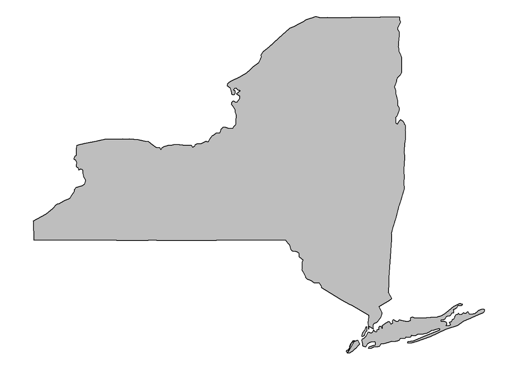

```r
usa <- map_data("usa")

states <- map_data("state")


ny_df <-  subset(states, region == "new york")
# head(ny_df)
counties <-  map_data("county")
ny_county <- subset(counties, region == "new york")
# head(ny_county)
ny_base <-  ggplot(data = ny_df, mapping = aes(x = long, y = lat, group = group)) +
  coord_fixed(1.3) +
  geom_polygon(color = "black", fill = "gray")
ny_base + theme_nothing()
```

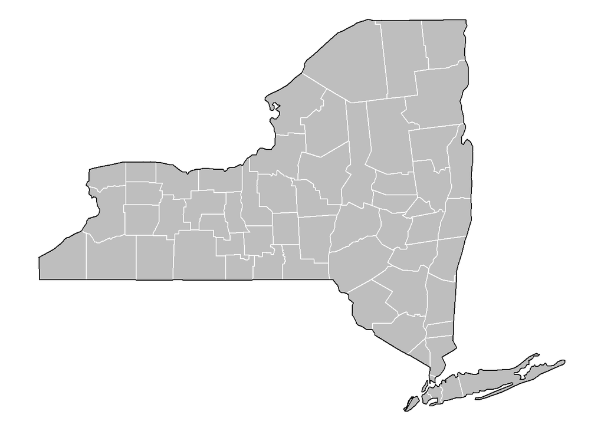

```r
ny_base + theme_nothing() +
  geom_polygon(data = ny_county, fill = NA, color = "white") +
  geom_polygon(color = "black", fill = NA) # get the state border back on top
```

### First visualization - Taxable Sales for one year by county

The data is filtered for a particiular year. This is identified as a variable so that it can be easily changed.

Taxable sales amounts are translated into millions, as the dollar amounts are extremely large.

NYS identifies all of the counties (5) of NYC as a single jurisdiction, so the mapping data is adjusted to reflect all 5 of these counties as 1 subregion.

Note that the NYS sales tax data includes jurisdictions such as “NY State” and “MCTD”. (MCTD is the Metropolitan Commuter Transportation District, which encompasses several counties in the NYC area.) Because NYS sales tax is actually 2 pieces - state imposed (including MCTD when applicable) and local share - and because imposition of sales tax may vary by jurisdiction/taxability (examples: clothing under $110 is exempt by the state but localities may choose whether or not to exempt, NYC imposes taxes on some itesm/services which are exempt from the tax at the state level, some jurisdictions choose to charge sales tax on residential utilites while they are exempt from the state sales tax), these jursidictions are being removed from analysis and we will only be looking at the taxables sales/purchases reported by jurisdiction only. The reason being that we do not know the detail of where the sale/purchase actually occured, and cannot compare them with other reporting jurisdictions. The data with these jurisdictions will be ignored when mapping because they do not correspond to a subregion in the mapping data. However, in other types of graphs, they will need to be filtered out.

For reference, the November 2019 quarterly sales tax return for monthly filers can be viewed here: https://www.tax.ny.gov/pdf/current_forms/st/st810.pdf Additional information regarding the exemption of clothing: https://www.tax.ny.gov/pdf/publications/sales/pub718c.pdf

Because the sales/purchases in NYC are so much more than the rest of the state, a log10 (logarithmic) transformation is used to adjust for the skewedness. Without doing this, the map shows NYC in one color and the rest of NYS in another color.

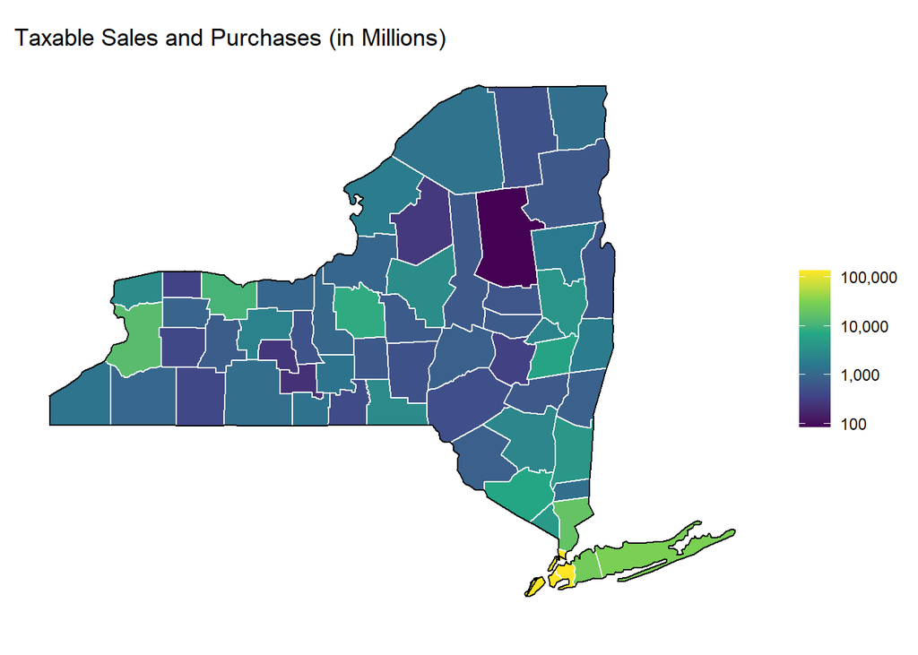

```r
map_year <- 2014

sales_tax <- sales_tax %>%
  mutate(st_year = substr(Sales.Tax.Year, 8, 11)) %>%
  mutate(Jurisdiction = tolower(Jurisdiction)) %>%
  mutate(T_Sales = Taxable.Sales.and.Purchases / 1000000)

colnames(sales_tax)[5] <- "subregion"

tax_year <- sales_tax %>%
  filter(st_year == map_year) %>%
  select(subregion, T_Sales, st_year) %>%
  group_by(subregion) %>%
  summarize(T_Sales = sum(T_Sales, na.rm = TRUE))

ny_county <- ny_county %>%
  mutate(subregion = replace(subregion, subregion %in% c("bronx", "richmond", "new york", "queens", "kings"), "ny city"))

county_sales <- inner_join(ny_county, tax_year, by = "subregion")

remove_background <- theme(
  axis.text = element_blank(),
  axis.line = element_blank(),
  axis.ticks = element_blank(),
  panel.border = element_blank(),
  panel.grid = element_blank(),
  axis.title = element_blank()
)

ny_taxable_sales <-  ny_base +
  geom_polygon(data = county_sales, aes(fill = T_Sales), color = "white") +
  geom_polygon(color = "black", fill = NA) +
  theme_bw() +
  remove_background

# This could be viewed, which has not been adjusted using a logarithmic transformation:
# ny_taxable_sales

ny_taxable_sales + scale_fill_viridis_c(trans = "log10",
                                        labels = comma) +
  labs(title = "Taxable Sales and Purchases (in Millions)",
       fill = element_blank())
```

#### Evaluation

This map is easy to interpret and differences between counties are fairly clear.

You’ll notice that the county at the heart of the Adirondacks, Hamilton County, is a much darker blue than any of the other couties. To my knowledge, this is a sparsely populated county. This led me to wonder how closely related population is to taxable sales/purchases.

#### Compare with population

I found population data by county on the Empire Center website: https://www.empirecenter.org/publications/population-new-york-and-u-s-nys-counties/

For easy identifying of the 62 counties of NYS (including the 5 which are NYC), I located a list of DOT’s county codes: https://www.dot.ny.gov/main/business-center/engineering/specifications/local-specifications/county-code

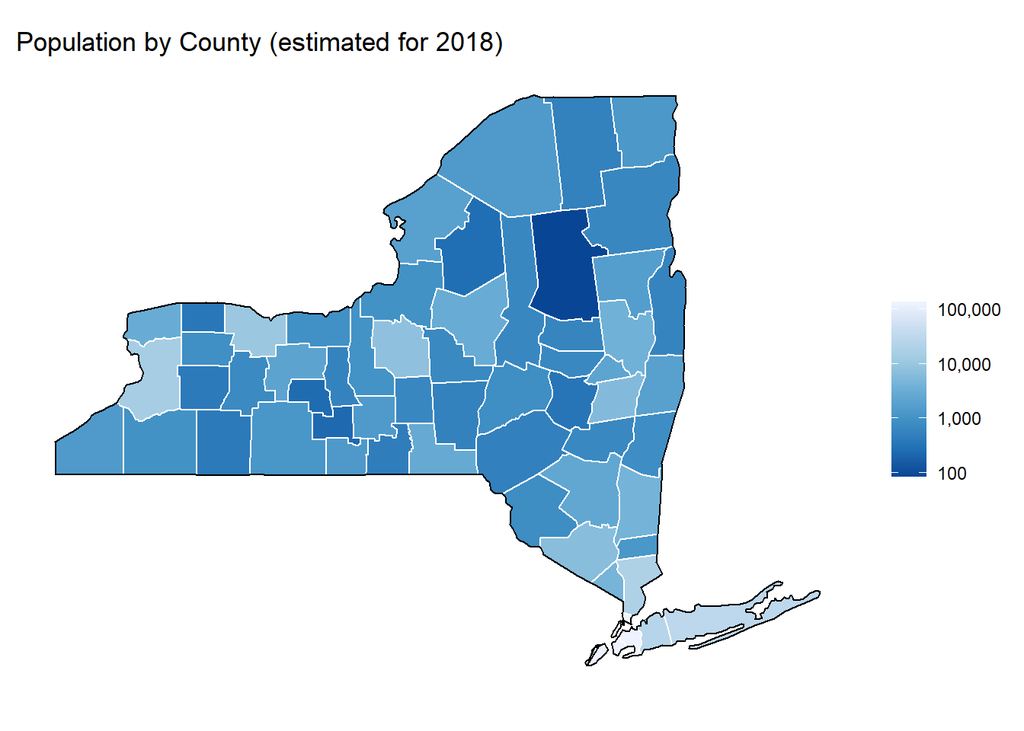

```r
ny_pop <- read.csv("data/ny_population.csv")

colnames(ny_pop)[1] <- "subregion"

ny_pop$subregion <- as.character(ny_pop$subregion)

county_pop <- inner_join(ny_county, ny_pop, by = "subregion")

ny_population <-  ny_base +
  geom_polygon(data = county_pop, aes(fill = Population), color = "white") +
  geom_polygon(color = "black", fill = NA) +
  theme_bw() +
  remove_background

# ny_population

ny_taxable_sales +
  scale_fill_distiller(trans = "log10", labels = comma) +
  labs(title =  "Population by County (estimated for 2018)",
       fill = element_blank())
```

#### Compare population to taxable sales/purchases

Next, I plotted the population (2018 estimate) against the taxable sales/purchases by county, using the DOT county codes to identify the plot points. There appears to be a very strong correlation. (Log 10 transformation is used for both population and taxable sales/purchases.)

*The code for Nassau County had to be changed from “NA” to “NS” as “NA” causes issues when interpretted by software such as r.

```r
tax_year_facet <- sales_tax %>%
  filter(subregion != "ny state") %>%
  filter(subregion != "mctd") %>%
  filter(st_year != 2020) %>%
  select(subregion, T_Sales, st_year) %>%
  group_by(subregion, st_year) %>%
  summarize(T_Sales = sum(T_Sales, na.rm = TRUE))
```

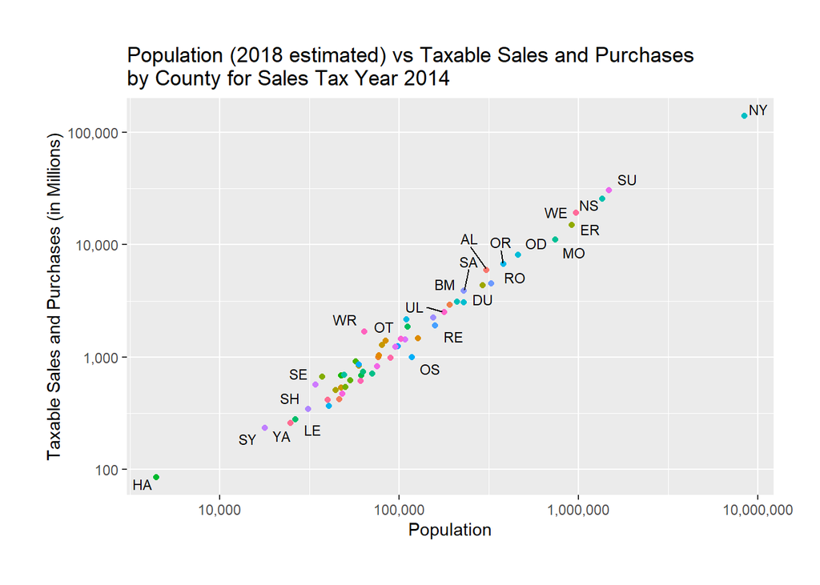

```r
tax_year_facet$st_year <- as.numeric(tax_year_facet$st_year)

sales_pop <- inner_join(ny_pop, tax_year_facet, by = "subregion")

sales_pop <- sales_pop %>%
   filter(st_year == map_year)

sales_pop$T_Sales <- as.numeric(sales_pop$T_Sales)
sales_pop$Population <- as.numeric(sales_pop$Population)

sales_pop$Code <- as.character(sales_pop$Code)
sales_pop$Code[which(is.na(sales_pop$Code))] <- "NS"

sales_pop_plot <- ggplot(sales_pop, aes(x = Population, y = T_Sales, group = subregion))
sales_pop_plot +
  geom_point(aes(color = subregion)) +
  scale_y_log10(labels = comma) +
  scale_x_log10(labels = comma) +
  geom_text_repel(aes(label = Code), size = 3) +
  guides(color = FALSE) +
  labs(title = paste("Population (2018 estimated) vs Taxable Sales and Purchases \nby County for Sales Tax Year", map_year),
       y = "Taxable Sales and Purchases (in Millions)") +
  theme(plot.margin = margin(1, 1, 1, 1, "cm"))
```

#### Evaluation

The relationship between population and taxable sales/purchases is interesting, and this visualization clearly shows the the close relationship which exists. It would also be interesting to view taxable sales/purchases in relation to income of each county to see if there is a stronger relationship between income and taxable sales/purchases or with population.

### Consider Taxable Sales and Purchases over time

Next, I used a line graph to look at whether or not taxable sales/purchases have increased or decreased significantly in any of the counties. I filter out 2020 because it is only a partial year (only 1 quarter reported) and would skew the graphs. I faceted this to show all jursidictions. There are no significant changes that can be determined from this visualization. This may be because of the range of taxable sales between Hamilton County (low end) and NYC (high end) when shown in this manner. Looking at an individual county by itself may reveal a change, but this visualization is not useful.

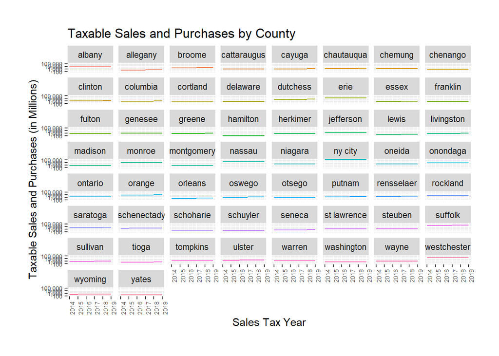

```r
sales_yr_plot <- ggplot(tax_year_facet, aes(x = st_year, y = T_Sales, group = subregion))
sales_yr_plot + geom_line(aes(color = subregion)) + facet_wrap(~ subregion) +
  scale_y_log10(labels = comma) +
  theme(legend.position = "none",
        axis.text.x = element_text(angle = 90, hjust = 1, size = 6),
        axis.text.y = element_text(size = 6)) +
  labs(title = "Taxable Sales and Purchases by County",
       x = "Sales Tax Year",
       y = "Taxable Sales and Purchases (in Millions)") +
  theme(plot.margin = margin(1, 1, 1, 1, "cm"))
```

#### Evaluation

This visualization is not useful. It may be useful if looked at a particular region of NYS, such as the Adirondacks or the Southern Tier, where only a handful of counties are being compared and the taxable sales/purchases are in a narrower range.

### Mapping by year

If we look at the taxable sales revenue by year, will we see any significant changes here that are not discernible in the line plot? Here, we have not filtered out the partial 2020 tax year reporting. Other than the significant difference shown by that partial tax year, nothing stands out. The taxable purchases/sales are consistent.

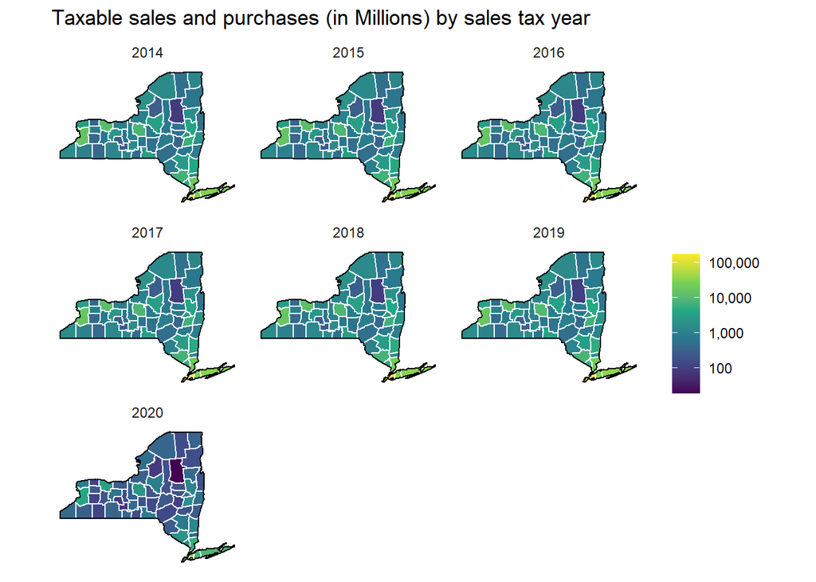

```r
map_year <- 2014

tax_year_facet <- sales_tax %>%
  select(subregion, T_Sales, st_year) %>%
  group_by(subregion, st_year) %>%
  summarize(T_Sales = sum(T_Sales, na.rm = TRUE))
county_sales_facet <- inner_join(ny_county, tax_year_facet, by = "subregion")

ny_taxable_sales_facet <-  ny_base +
  geom_polygon(data = county_sales_facet, aes(fill = T_Sales), color = "white") +
  geom_polygon(color = "black", fill = NA) +
  theme_bw() +
  remove_background

ny_taxable_sales_facet +
  scale_fill_viridis_c(trans = "log10", labels = comma) +
  facet_wrap(~ st_year, nrow = 3) +
  labs(title =  "Taxable sales and purchases (in Millions) by sales tax year",
       fill = element_blank()) +
  theme(strip.background = element_rect(
    color = "white", fill = "white")
  )
```

#### Evaluation

This visualization could be useful if there were significant changes, as we see from the partial year (2020) shown here. We might also be able to see more variance if we were to exclude counties from Orange/Putnam and south, since those counties have significantly more taxable sales/purchases and skew the data.

### Sources of Taxable sales and purchases

For each county, it might be useful to know what the biggest source of revenue is. Here, I’ve mapped the top source of revenue for each county.

First note the brown county downstate. This is Orange County, where Woodbury Commons, an outlet mall is. The brown indicates that the top revenue is clothing stores. Orange County is a county which chooses to impose their portion of the sales tax on all clothing purchases. Remember that we are looking at taxable sales/purchases, not tax revenue, so this is not surprising.

The rest of the state is mostly automobile dealers and gasoline stations.

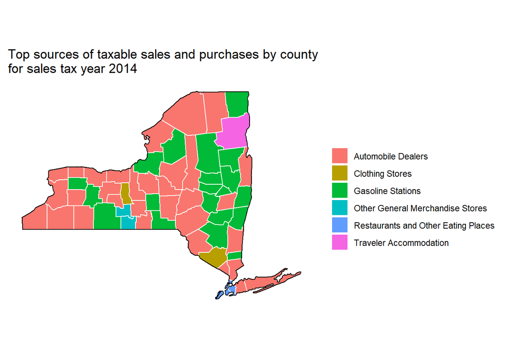

```r
sales_tax_naics <- sales_tax %>%
  mutate(NAICS = substr(NAICS.Industry.Group, 1, 2)) %>%
  filter(st_year == map_year) %>%
  select(subregion, NAICS.Industry.Group, Description, Taxable.Sales.and.Purchases, st_year, T_Sales, NAICS) %>%
  mutate(key = paste(subregion, Description, sep = " "))

NAICS <- read.csv("data/NAICS.csv")

NAICS$Code <- as.character(NAICS$Code)

colnames(NAICS)[1] <- "NAICS"

sales_tax_naics <- left_join(sales_tax_naics, NAICS, by = "NAICS")

sales_tax_naics_sum <- sales_tax_naics %>%
  group_by(subregion, key, .drop = FALSE) %>%
  summarize(T_Sales = sum(T_Sales, na.rm = TRUE))
sales_tax_naics_sum <- sales_tax_naics_sum[order(sales_tax_naics_sum$subregion, -sales_tax_naics_sum$T_Sales),]

sales_tax_naics_join <- sales_tax_naics %>%
  mutate(key = paste(subregion, Description, sep = " ")) %>%
  select(NAICS.Industry.Group, Description, st_year, NAICS, key)

sales_tax_naics <- left_join(sales_tax_naics_sum, sales_tax_naics_join, by = "key")

sales_tax_naics <- sales_tax_naics[order(sales_tax_naics$subregion, -sales_tax_naics$T_Sales),]

sales_tax_naics <- sales_tax_naics %>%
  group_by(subregion) %>%
  top_n(1, T_Sales)

naics_sales <- inner_join(ny_county, sales_tax_naics, by = "subregion")

ny_naics <-  ny_base +
  geom_polygon(data = naics_sales, aes(fill = Description), color = "white") +
  geom_polygon(color = "black", fill = NA) +
  theme_bw() +
  remove_background

ny_naics +
  labs(title =  paste("Top sources of taxable sales and purchases by county \nfor sales tax year", map_year),
       fill = element_blank())
```

#### Evaluation

This is a good visualization, making it easy to identify each county’s top source of taxable sales/purchases. Are the sources consistent over time?

#### Top source of taxable sales and purchases by tax year

If we look at the top source by county over each sales tax year, has this changed? We see that over the first couple of years, gasoline stations are the number 1 source in many counties, but that changed after 2015.

I went to Google to find out if gasoline prices were high in 2014 and 2015, and found that yes, they were significantly higher in 2014. Source: https://www.usinflationcalculator.com/gasoline-prices-adjusted-for-inflation/

Starting with this visualization, I’ve had to try different color scales, as some color scales resulted in maps where the sources could not be identified (ie, two different greens were too close together to tell them apart).

```r
st_naics_facet <- sales_tax %>%
  mutate(NAICS = substr(NAICS.Industry.Group, 1, 2)) %>%
  select(subregion, NAICS.Industry.Group, Description, Taxable.Sales.and.Purchases, st_year, T_Sales, NAICS) %>%
  mutate(key = paste(subregion, Description, sep = " ")) %>%
  mutate(key_group = paste(key, st_year, sep = " "))

st_naics_facet <- left_join(st_naics_facet, NAICS, by = "NAICS")

st_naics_sum_facet <- st_naics_facet %>%
  group_by(subregion, st_year, key, key_group, .drop = FALSE) %>%
  summarize(T_Sales = sum(T_Sales, na.rm = TRUE))
```

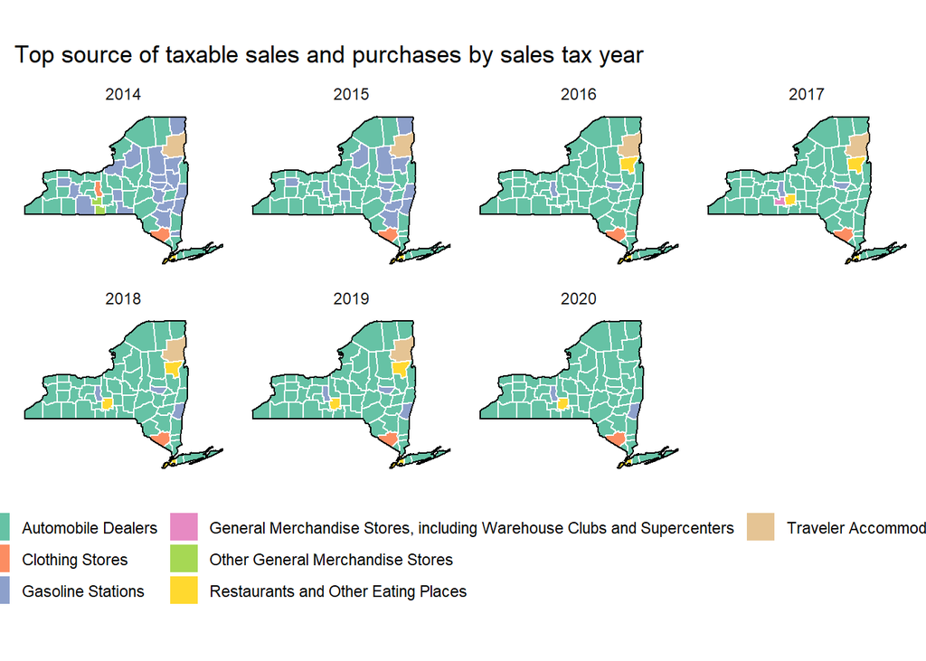

```r
st_naics_sum_facet <- st_naics_sum_facet[order(st_naics_sum_facet$st_year, st_naics_sum_facet$subregion, -st_naics_sum_facet$T_Sales),]

st_naics_join_facet <- st_naics_facet %>%
  select(NAICS.Industry.Group, Description, NAICS, key_group)

st_naics_facet <- left_join(st_naics_sum_facet, st_naics_join_facet, by = "key_group")

st_naics_facet <- st_naics_facet[order(st_naics_facet$st_year, st_naics_facet$subregion, -st_naics_facet$T_Sales),]

st_naics_facet <- st_naics_facet %>%
  group_by(st_year, subregion) %>%
  top_n(1, T_Sales)

naics_sales_facet <- inner_join(ny_county, st_naics_facet, by = "subregion")

levels(naics_sales_facet$Description) <- gsub("Warehouse", "\nWarehouse", levels(naics_sales_facet$Description))

ny_naics_facet <-  ny_base +
  geom_polygon(data = naics_sales_facet, aes(fill = Description), color = "white") +
  geom_polygon(color = "black", fill = NA) +
  theme_bw() +
  remove_background

legend_facet <- ny_naics_facet + facet_wrap(~ st_year, nrow = 2) +
  labs(title =  "Top source of taxable sales and purchases by sales tax year",
       fill = element_blank()) +
  theme(strip.background = element_rect(
    color = "white", fill = "white"),
    legend.position = "bottom")

legend_facet +
  scale_fill_brewer(palette = "Set2", guide = guide_legend(ncol = 3))
```

#### Evaluation

Vehicles are probably the second biggest expense for most households outside of NYC, other than housing. Sales tax generally does not apply to housing. Let’s take automobile dealers out of the data, since that is the biggest source of taxable sales/purchases in most of the counties.

I also noted that in the map of sourches of taxable sales/purhcases for 2019, I noticed that 2 of the 3 counties which are still showing gasoline stations (after gas stations as the number one source fell from 2014) as their biggest taxable sales/purchases source are Montgomgery and Columbia Counties, which both have large truck stops right off I-90 and are otherwise rather rural counties.

```r
excl_NAICS <- "Automobile Dealers"

st_naics_excl <- sales_tax %>%
  filter(Description != excl_NAICS) %>%
  mutate(NAICS = substr(NAICS.Industry.Group, 1, 2)) %>%
  select(subregion, NAICS.Industry.Group, Description, Taxable.Sales.and.Purchases, st_year, T_Sales, NAICS) %>%
  mutate(key = paste(subregion, Description, sep = " ")) %>%
  mutate(key_group = paste(key, st_year, sep = " "))

st_naics_excl <- left_join(st_naics_excl, NAICS, by = "NAICS")

st_naics_sum_excl <- st_naics_excl %>%
  group_by(subregion, st_year, key, key_group, .drop = FALSE) %>%
  summarize(T_Sales = sum(T_Sales, na.rm = TRUE))
```

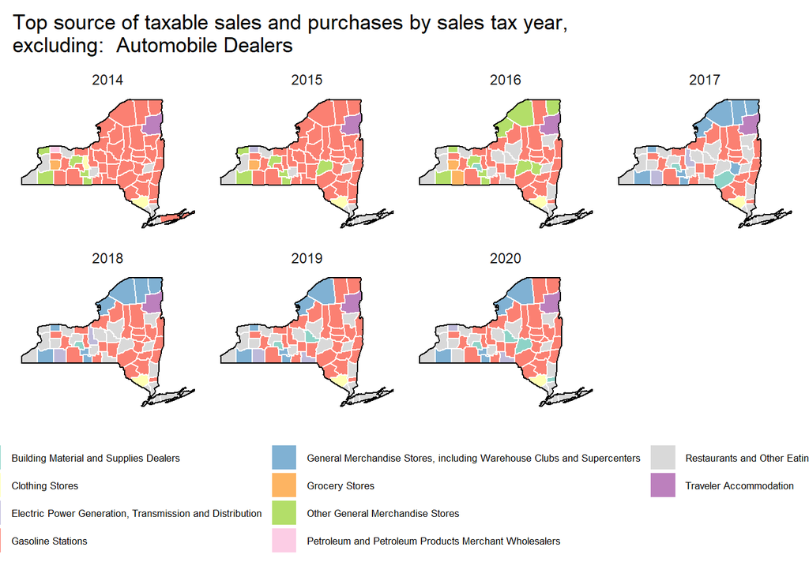

```r
st_naics_sum_excl <- st_naics_sum_excl[order(st_naics_sum_excl$st_year, st_naics_sum_excl$subregion, -st_naics_sum_excl$T_Sales),]

st_naics_join_excl <- st_naics_excl %>%
  select(NAICS.Industry.Group, Description, NAICS, key_group)

st_naics_excl <- left_join(st_naics_sum_excl, st_naics_join_excl, by = "key_group")

st_naics_excl <- st_naics_excl[order(st_naics_excl$st_year, st_naics_excl$subregion, -st_naics_excl$T_Sales),]

st_naics_excl <- st_naics_excl %>%
  group_by(st_year, subregion) %>%
  top_n(1, T_Sales)

naics_sales_excl <- inner_join(ny_county, st_naics_excl, by = "subregion")

levels(naics_sales_excl$Description) <- gsub("Warehouse", "\nWarehouse", levels(naics_sales_excl$Description))

ny_naics_excl <-  ny_base +
  geom_polygon(data = naics_sales_excl, aes(fill = Description), color = "white") +
  geom_polygon(color = "black", fill = NA) +
  theme_bw() +
  remove_background

ny_naics_excl + facet_wrap(~ st_year, nrow = 2) +
  labs(title =  paste("Top source of taxable sales and purchases by sales tax year, \nexcluding: ", excl_NAICS),
       fill = element_blank()) +
  theme(strip.background = element_rect(
    color = "white", fill = "white"),
    legend.position = "bottom",
    legend.text = element_text(size = 6.25)
  ) +  scale_fill_brewer(palette = "Set3", guide = guide_legend(ncol = 3))
```

#### Gasoline Stations

We’re getting more information from mapping the top source when excluding automobile dealers. However, gasoline stations are appearing a lot more as the biggest source. We know that gas prices move for geopolitical or other reasons, not always with inflation, so let’s try excluding them as well.

Note that based on the maps, it appears that there may have been a change in reporting terminology between 2016 and 2017 related to General Merchandise Stores.

```r
excl_NAICS_2 <- "Gasoline Stations"

st_naics_excl_2 <- sales_tax %>%
  filter(Description != excl_NAICS) %>%
  filter(Description != excl_NAICS_2) %>%
  mutate(NAICS = substr(NAICS.Industry.Group, 1, 2)) %>%
  select(subregion, NAICS.Industry.Group, Description, Taxable.Sales.and.Purchases, st_year, T_Sales, NAICS) %>%
  mutate(key = paste(subregion, Description, sep = " ")) %>%
  mutate(key_group = paste(key, st_year, sep = " "))

st_naics_excl_2 <- left_join(st_naics_excl_2, NAICS, by = "NAICS")

st_naics_sum_excl_2 <- st_naics_excl_2 %>%
  group_by(subregion, st_year, key, key_group, .drop = FALSE) %>%
  summarize(T_Sales = sum(T_Sales, na.rm = TRUE))
```

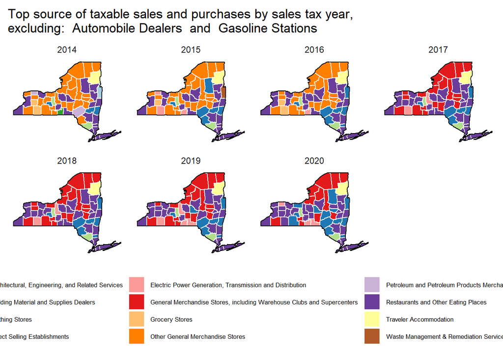

```r
st_naics_sum_excl_2 <- st_naics_sum_excl_2[order(st_naics_sum_excl_2$st_year, st_naics_sum_excl_2$subregion, -st_naics_sum_excl_2$T_Sales),]

st_naics_join_excl_2 <- st_naics_excl_2 %>%
  select(NAICS.Industry.Group, Description, NAICS, key_group)

st_naics_excl_2 <- left_join(st_naics_sum_excl_2, st_naics_join_excl_2, by = "key_group")

st_naics_excl_2 <- st_naics_excl_2[order(st_naics_excl_2$st_year, st_naics_excl_2$subregion, -st_naics_excl_2$T_Sales),]

st_naics_excl_2 <- st_naics_excl_2 %>%
  group_by(st_year, subregion) %>%
  top_n(1, T_Sales)

naics_sales_excl_2 <- inner_join(ny_county, st_naics_excl_2, by = "subregion")

levels(naics_sales_excl_2$Description) <- gsub("Warehouse", "\nWarehouse", levels(naics_sales_excl_2$Description))

levels(naics_sales_excl_2$Description) <- gsub("and Distribution", "\nand Distribution", levels(naics_sales_excl_2$Description))

levels(naics_sales_excl_2$Description) <- gsub("Wholesalers", "\nWholesalers", levels(naics_sales_excl_2$Description))

ny_naics_excl_2 <-  ny_base +
  geom_polygon(data = naics_sales_excl_2, aes(fill = Description), color = "white") +
  geom_polygon(color = "black", fill = NA) +
  theme_bw() +
  remove_background

ny_naics_excl_2 +
  facet_wrap(~ st_year, nrow = 2) +
  labs(title = paste("Top source of taxable sales and purchases by sales tax year, \nexcluding: ", excl_NAICS, " and ", excl_NAICS_2),
       fill = element_blank()) +
  theme(strip.background = element_rect(
    color = "white", fill = "white"),
    legend.position = "bottom",
    legend.text = element_text(size = 6.25)
  ) +  scale_fill_brewer(palette = "Paired", guide = guide_legend(ncol = 3))
```

#### Evaluation

This visualization is a quick way to get an idea for what are the biggest sources of taxable sales/purchases by county. However, the theory of the change in reporting for general merchandise stores would have to be investigated, and data may need to be cleaned. This visualizaton may be most useful when limited to only a few reporting years at once (perhaps only every other year), to look for changes over time. Otherwise, the map of 1 year is sufficient.

### Top 10 sources

What are the biggest sources, not just the top source, of taxable sales/purchases?

```r
select_county <- "ny city"

ranked_sales <- sales_tax %>%
#  filter(subregion == select_county) %>%
  group_by(st_year, Description, .drop = FALSE) %>%
  summarize(T_Sales = sum(T_Sales, na.rm = TRUE))
```

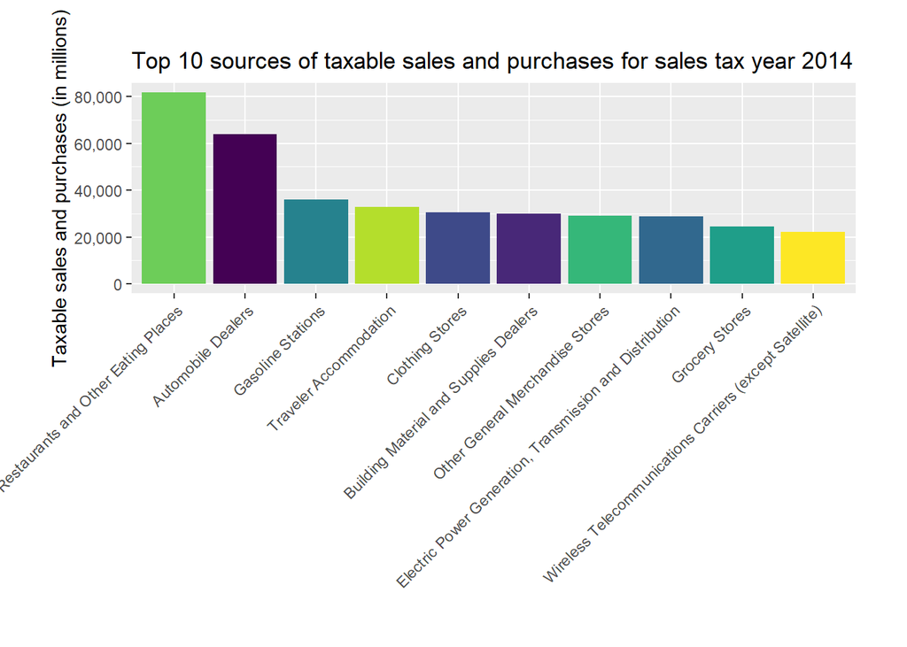

```r
ranked_sales <- ranked_sales %>%
  group_by(st_year) %>%
  top_n(10, T_Sales)

ranked_sales_year <- ranked_sales %>%
  filter(st_year == map_year)

ranked_sales_year <- ranked_sales_year[order(-ranked_sales_year$T_Sales),]

levels(ranked_sales_year$Description) <- gsub(",", ",\n", levels(ranked_sales_year$Description))

levels(ranked_sales_year$Description) <- gsub(" Carriers", "\nCarriers", levels(ranked_sales_year$Description))

levels(ranked_sales_year$Description) <- gsub(" Other", ",\nOther", levels(ranked_sales_year$Description))

levels(ranked_sales_year$Description) <- gsub(" Supplies", ",\nSupplies", levels(ranked_sales_year$Description))

levels(ranked_sales_year$Description) <- gsub(" Merchandise", ",\nMerchandise", levels(ranked_sales_year$Description))

ggplot(ranked_sales_year, aes(x = reorder(Description, -T_Sales), y = T_Sales, fill = Description)) +
  geom_bar(stat = "identity", position = "dodge") +
  labs(title = paste("Top 10 sources of taxable sales and purchases for sales tax year", map_year),
       x = element_blank(),
       y = "Taxable sales and purchases (in millions)") +
  scale_y_continuous(label = comma) +
  scale_fill_viridis_d() +
  theme(legend.position = "none",
        axis.text.x = element_text(angle = 45, hjust = 1)) +
  theme(plot.margin = margin(1, 1, 1, 1, "cm"))
```

#### Evaluation

This visualization shows the top 10 sources of taxable sales/purchases for the entire state. It’s interesting that automobile dealers are not at the top, given how many counties they were the top source for. This is likely due in part to the NYC reported amounts weighting the category in this graph. This visualization would be most useful when viewed for a particular county, not for the entire state.

### Taxable sales and purchaes by quarter

The only piece of data which we have not investigated further is the taxable sales and purchases by quarter.

```r
st_qtrs <- sales_tax %>%
  filter(subregion != "ny state") %>%
  filter(subregion != "mctd") %>%
  group_by(st_year, Sales.Tax.Quarter, .drop = FALSE) %>%
  summarize(T_Sales = sum(T_Sales, na.rm = TRUE))
```

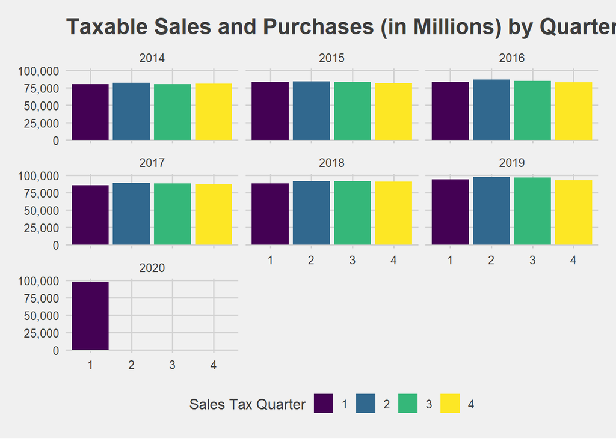

```r
st_qtrs$Sales.Tax.Quarter <- as.factor(st_qtrs$Sales.Tax.Quarter)

qtrs_bar <- ggplot(st_qtrs, aes(x = Sales.Tax.Quarter, y = T_Sales, fill = Sales.Tax.Quarter)) +
  geom_bar(stat = "identity", position = "dodge") +
  labs(title = "Taxable Sales and Purchases (in Millions) by Quarter",
       x = "Sales Tax Quarter",
       y = "Taxable sales and purchases (in millions)") +
  facet_wrap(~ st_year)

qtrs_bar +
  scale_fill_viridis_d(name = "Sales Tax Quarter") +
  scale_y_continuous(labels = comma) +
  theme_fivethirtyeight()
```

#### Evaluation

The taxable sales/purchases are fairly consistent by quarter. There are no quarters which seem to typically have a much higher reported taxable sales/purchases. This visualization is not very useful, and I do not believe it would be moreso if we looked at one year rather than many.